# 당뇨병 유무 예측 및 핵심 인자 발굴

SY

2026-04-22

## 1. 서론(Introduction)

본 분석은 피마 인디언 당뇨 데이터셋을 활용하여 생체 지표(혈당, BMI 등)가 당뇨병 발병에 미치는 영향을 분석하고, 머신러닝 모델을 통해 발병 여부를 예측하는 것을 목적으로 함.

## 2. 데이터 준비 및 전처리

데이터 구조 확인 중 이상치 발견

-> 이상치 제거 후 데이터 수 감소 (768 -> 392)

```r
library(mlbench)
data(PimaIndiansDiabetes)
df <- PimaIndiansDiabetes

# 데이터 구조 확인
str(df)
```

```
## 'data.frame':    768 obs. of  9 variables:
##  $ pregnant: num  6 1 8 1 0 5 3 10 2 8 ...
##  $ glucose : num  148 85 183 89 137 116 78 115 197 125 ...
##  $ pressure: num  72 66 64 66 40 74 50 0 70 96 ...
##  $ triceps : num  35 29 0 23 35 0 32 0 45 0 ...
##  $ insulin : num  0 0 0 94 168 0 88 0 543 0 ...
##  $ mass    : num  33.6 26.6 23.3 28.1 43.1 25.6 31 35.3 30.5 0 ...
##  $ pedigree: num  0.627 0.351 0.672 0.167 2.288 ...
##  $ age     : num  50 31 32 21 33 30 26 29 53 54 ...
##  $ diabetes: Factor w/ 2 levels "neg","pos": 2 1 2 1 2 1 2 1 2 2 ...
```

```r
head(df)
```

```
##   pregnant glucose pressure triceps insulin mass pedigree age diabetes
## 1        6     148       72      35       0 33.6    0.627  50      pos
## 2        1      85       66      29       0 26.6    0.351  31      neg
## 3        8     183       64       0       0 23.3    0.672  32      pos
## 4        1      89       66      23      94 28.1    0.167  21      neg
## 5        0     137       40      35     168 43.1    2.288  33      pos
## 6        5     116       74       0       0 25.6    0.201  30      neg
```

```r
# 이상치 발견 및 처리
library(dplyr)
df_final <- df %>%
  mutate(across(c(glucose, pressure, triceps, insulin, mass, age, pedigree),
                ~ ifelse(. == 0, NA, .))) %>%
  filter(complete.cases(.))
```

## 3. 탐색적 데이터 분석 (EDA)

결측치 및 이상치 유무 확인과 변수 간의 상관성 확인을 통해 데이터 타당성 검토.

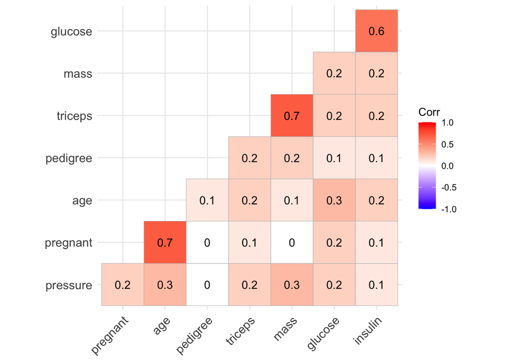

```r
# 상관관계 분석 및 시각화
library(ggcorrplot)
corr <- round(cor(df_final[, -9]), 1) # 마지막 열(당뇨유무) 제외하고 계산, 소숫점 1자리까지 표기
ggcorrplot(corr, hc.order = TRUE, type = "lower", lab = TRUE)
```

## 4. 머신러닝 모델 구축

분석의 재현성을 높이기 위해 기준점 생성 후 전체 70%에 해당하는 행을 무작위 추첨.

-> 이를 학습용으로 지정.

-> 남은 30%를 시험용으로 지정.

추첨된 274개의 행 중에 *Diabetes*를 제외한 나머지 변수들과 *Diabetes* 유무 사이의 관계 학습.

-> 새로운 변수값을 넣었을 때 당뇨일 확률(0~1) 분석.

```r
set.seed(123) #분석의 재현성을 보장하기 위함.
idx <- sample(1:nrow(df_final), nrow(df_final) * 0.7)
train_data <- df_final[idx, ]
test_data  <- df_final[-idx, ]

# 로지스틱 회귀 모델 생성
model <- glm(diabetes ~ ., data = train_data, family = "binomial")
```

이상치 제거로 인해 데이터량이 절반 가량 줄었으므로, 각 변수의 *P-value*값 확인.

-> 이상치 제거 전에는 여러 변수가 중요해 보였으나, 정제 후 분석 결과 *Glucose*만 압도적 유의성을 보임.

-> 기존에 중요하게 나타났던 *Pregnant*는 이상치를 제거하자 통계적 유의성을 잃었음.

```r
summary(model)
```

```
##
## Call:
## glm(formula = diabetes ~ ., family = "binomial", data = train_data)
##
## Coefficients:
##               Estimate Std. Error z value Pr(>|z|)
## (Intercept) -1.047e+01  1.480e+00  -7.075 1.49e-12 ***
## pregnant    -1.818e-02  6.877e-02  -0.264   0.7915
## glucose      4.384e-02  7.520e-03   5.830 5.54e-09 ***
## pressure    -8.082e-03  1.559e-02  -0.518   0.6042
## triceps      4.754e-03  2.086e-02   0.228   0.8197
## insulin     -6.464e-04  1.651e-03  -0.391   0.6955
## mass         8.197e-02  3.460e-02   2.369   0.0178 *
## pedigree     1.115e+00  5.234e-01   2.130   0.0332 *
## age          4.628e-02  2.310e-02   2.004   0.0451 *
## ---
## Signif. codes:  0 '***' 0.001 '**' 0.01 '*' 0.05 '.' 0.1 ' ' 1
##
## (Dispersion parameter for binomial family taken to be 1)
##
##     Null deviance: 353.67  on 273  degrees of freedom
## Residual deviance: 237.71  on 265  degrees of freedom
## AIC: 255.71
##
## Number of Fisher Scoring iterations: 5
```

## 5. 시각화 (Visualization)

#### 1) 변수 중요도 (Feature Importance)

- 학습 이후 당뇨 유무 예측에 가장 효과있는 변수 확인.
- *model* 전체 중 각 변수의 영향력값 추출 후 절대값 확인.

  -> *important*로 지정.

  -> *important*가 높은 순으로 막대그래프 생성.

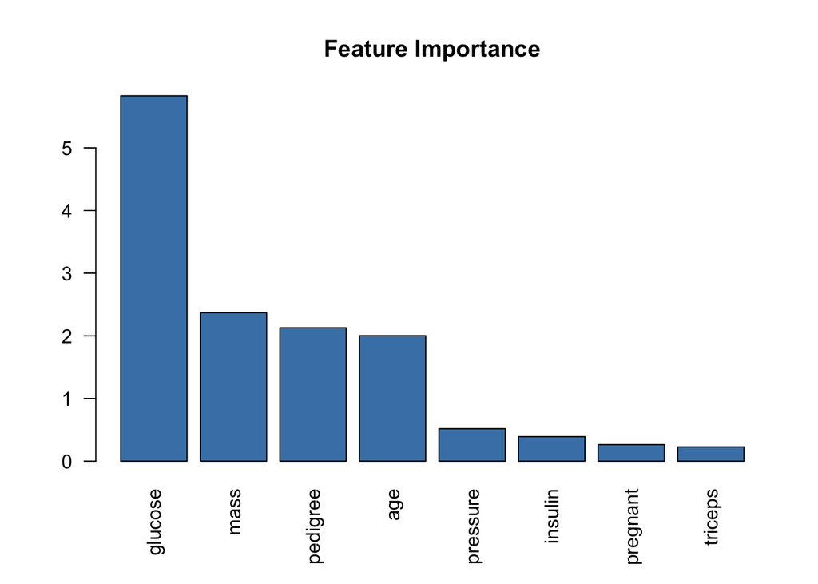

```r
# 변수 중요도 시각화
importance <- abs(summary(model)$coefficients[-1, "z value"])
barplot(sort(importance, decreasing = TRUE), col = "steelblue", las = 2, main = "Feature Importance")
```

#### 2) ROC 커브와 AUC

- 학습 모델의 결과값 그래프 도출.
- test_data 결과 도출.(0~1 사이값)

  -> 실제 결과값과 예측값 대조 후 roc_obj로 지정

  -> 그래프 생성

  -> 가로축: 오답을 정답으로 한 비율, 세로축: 정답을 정답으로 한 비율

```r
# ROC 커브 시각화
library(pROC)
pred <- predict(model, newdata = test_data, type = "response")
roc_obj <- roc(test_data$diabetes, pred)
```

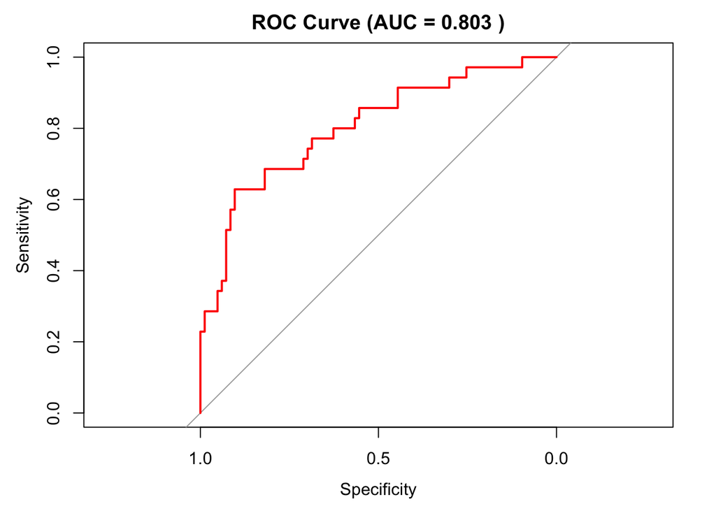

```r
plot(roc_obj, col = "red", main = paste("ROC Curve (AUC =", round(auc(roc_obj), 3), ")"))
```

## 6. 결론

#### Model 성능 분석

이상치를 제거하여 데이터가 768개에서 392개로 감소했음에도 불구하고, *AUC* 수치가 0.803으로 나타남. 이는 *Model*이 새로운 데이터를 접했을 때 당뇨 여부를 상당히 높은 정확도로 예측 가능하다고 판단할 수 있음.

#### 핵심 예측 인자

당뇨 예측의 가장 결정적인 영향을 미치는 핵심 인자는 *Glucose*이며, 뒤를 이어 *Mass, Pedigree, Age*가 유의미한 예측 인자로 확인됨(P < 0.05).

반면, 기존 분석에서 중요하게 다뤄졌던 *Pregnant*는 이상치 제거 후 통계적 유의성을 상실함(P-value 0.79). 이는 측정 오류가 포함된 데이터가 모델의 판단을 왜곡시킬 수 있음을 보여주며, 당뇨 예측에는 임신 횟수보다 내과적 지표와 유전적 요인이 더 본질적인 인자임을 입증함.

#### 추가로 수행해야할 분석

**1.Model의 교차 검증**

-> 난수 시드값을 다양하게 적용하여 특정 데이터에만 편향된 것이 아님을 입증해야함.

**2.변수 선택 최적화**

-> 유의미하지 않은 인자들을 제외한 간소화된 모델의 성능 변화를 확인할 필요가 있음.